# Proyección de Inflación en Bolivia

SARIMA, SARIMAX e Intervenciones

Análisis Econométrico

16 de julio de 2026

# 1 Datos y Descomposición Estacional

Serie: **log(IPC)** desde enero 2019 (90 observaciones mensuales). Período suficiente para estimar componentes estacionales con $s = 12$.

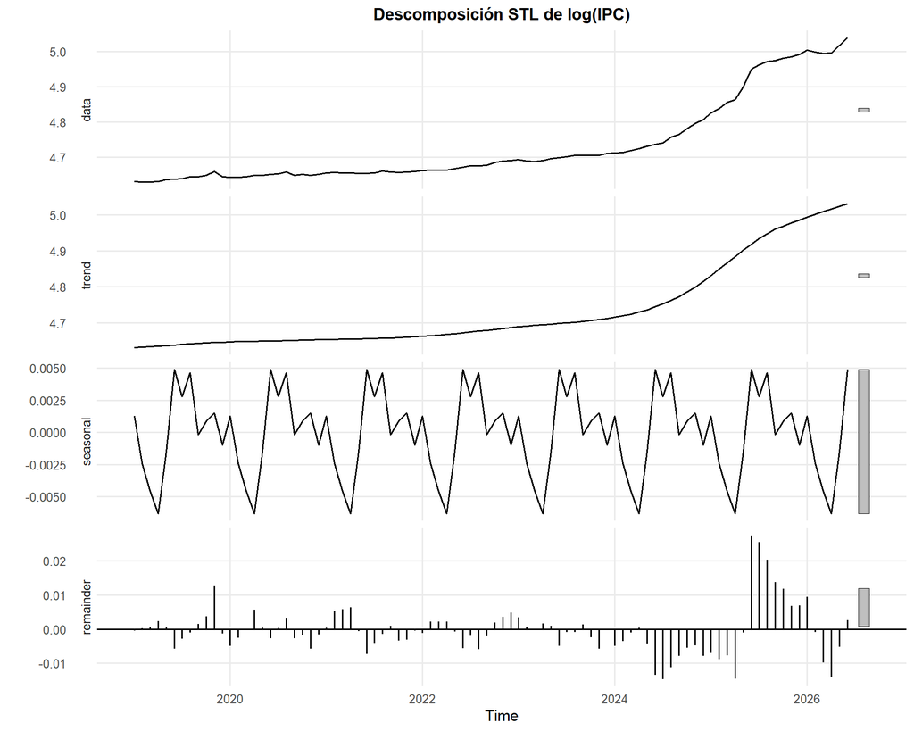

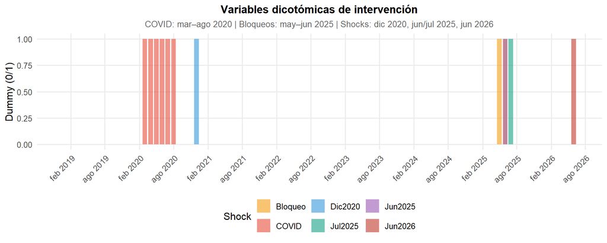

# 2 Pruebas de Raíz Unitaria y Estacionalidad

Pruebas de raíz unitaria

| Prueba | H₀ | Rechazo | Serie | Estadístico | p-valor | Conclusión |
| --- | --- | --- | --- | --- | --- | --- |
| **log(IPC)** |  |  |  |  |  |  |
| ADF | Raíz unitaria | p<0.05 → Estac. | log(IPC) | -0.0886 | 0.9900 | No estac. |
| PP | Raíz unitaria | p<0.05 → Estac. | log(IPC) | 0.5352 | 0.9900 | No estac. |
| KPSS | Estac. en tendencia | p<0.05 → No estac. | log(IPC) | 0.5043 | 0.0100 | No estac. |
| Zivot-Andrews | Raíz unitaria (sin quiebre) | p<0.05 → Estac. con quiebre | log(IPC) | -2.6357 | 0.1000 | No estac. |
| **Δlog(IPC)** |  |  |  |  |  |  |
| ADF | Raíz unitaria | p<0.05 → Estac. | Δlog(IPC) | -2.8654 | 0.2201 | No estac. |
| PP | Raíz unitaria | p<0.05 → Estac. | Δlog(IPC) | -52.2823 | 0.0100 | Estac. |
| KPSS | Estac. en nivel | p<0.05 → No estac. | Δlog(IPC) | 1.0432 | 0.0100 | No estac. |
| Zivot-Andrews | Raíz unitaria (sin quiebre) | p<0.05 → Estac. con quiebre | Δlog(IPC) | -3.7779 | 0.1000 | No estac. |

> Zivot-Andrews (quiebre en intercepto): quiebre detectado en **sept 2024** (log(IPC)) y **jul 2024** (Δlog(IPC)).

> Diferenciación regular recomendada: **d = 1**. Diferenciación estacional: **D = 0**.

> Para Δlog(IPC) las tres pruebas no coinciden entre sí (ADF p = 0.22, PP p = 0.01, KPSS p = 0.01), por lo que la evidencia de estacionariedad tras diferenciar es mixta. En consecuencia, `d = 1` se adopta por parsimonia — no como conclusión unívoca de las pruebas — y se valida más adelante con diagnóstico residual, criterios de información y backtesting.

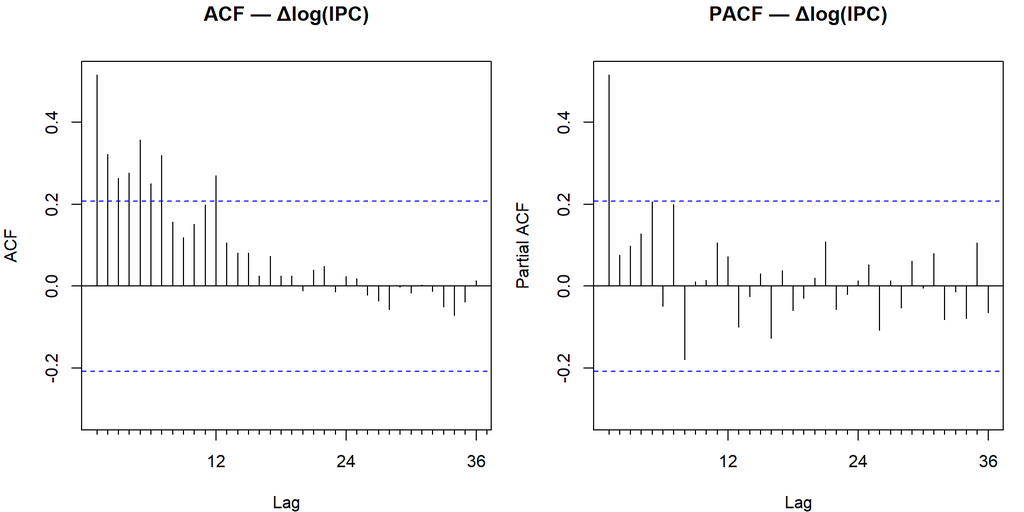

# 3 Modelo A: SARIMA Puro

Se estiman SARIMA$(p,d,q)(P,D,Q)_{12}$ sobre log(IPC) con $d=1$, $D=0$, $p,q \in [0,3]$, $P,Q \in [0,1]$.

Modelo A: SARIMA puro — Top 15 de 63 modelos

| Modelo | AICc | BIC | HQ | RMSE | MAPE | LB(p) | Score |
| --- | --- | --- | --- | --- | --- | --- | --- |
| (2,1,2)(1,0,0)[12] | -622.69 | -608.79 | -617.70 | 0.00665 | 0.088 | 0.4098 | -2.325 |
| (2,1,2)(0,0,1)[12] | -622.38 | -608.48 | -617.39 | 0.00668 | 0.088 | 0.3959 | -2.252 |
| (3,1,3)(1,0,0)[12] | -619.30 | -601.19 | -613.07 | 0.00649 | 0.086 | 0.2152 | -2.051 |
| (3,1,2)(1,0,0)[12] | -621.34 | -605.31 | -615.71 | 0.00662 | 0.087 | 0.4223 | -1.995 |
| (3,1,2)(0,0,1)[12] | -621.06 | -605.03 | -615.43 | 0.00662 | 0.087 | 0.4074 | -1.982 |
| (2,1,2)(1,0,1)[12] | -621.75 | -605.72 | -616.11 | 0.00659 | 0.088 | 0.3522 | -1.975 |
| (2,1,3)(0,0,1)[12] | -620.91 | -604.87 | -615.27 | 0.00663 | 0.088 | 0.3932 | -1.888 |
| (3,1,2)(1,0,1)[12] | -620.42 | -602.31 | -614.20 | 0.00653 | 0.087 | 0.3793 | -1.845 |
| (3,1,3)(1,0,1)[12] | -617.87 | -597.75 | -611.12 | 0.00642 | 0.085 | 0.1641 | -1.790 |
| (2,1,3)(1,0,1)[12] | -620.36 | -602.25 | -614.13 | 0.00653 | 0.087 | 0.3737 | -1.776 |
| (3,1,3)(0,0,1)[12] | -618.67 | -600.56 | -612.44 | 0.00650 | 0.086 | 0.1806 | -1.773 |
| (1,1,0)(1,0,1)[12] | -620.39 | -610.91 | -616.85 | 0.00692 | 0.089 | 0.4134 | -1.729 |
| (1,1,0)(1,0,0)[12] | -621.49 | -614.30 | -618.76 | 0.00701 | 0.091 | 0.4163 | -1.632 |
| (2,1,1)(1,0,0)[12] | -621.51 | -609.79 | -617.22 | 0.00685 | 0.090 | 0.4732 | -1.619 |
| (2,1,1)(1,0,1)[12] | -620.47 | -606.56 | -615.47 | 0.00675 | 0.089 | 0.4314 | -1.589 |

> **Ganador A:** (2,1,2)(1,0,0)[12] (Score = -2.325)

# 4 Modelo B: SARIMA + Intervenciones

Se agregan dummies de **COVID** (mar–ago 2020), **Bloqueos** (may–jun 2025) y shocks puntuales (dic 2020, jun/jul 2025, jun 2026) como regresores exógenos al SARIMA. Esto permite capturar los shocks sin que contaminen la estructura ARMA.

Modelo B: SARIMA + Intervenciones — Top 15 de 63 modelos

| Modelo | AICc | BIC | HQ | RMSE | MAPE | LB(p) | Score |
| --- | --- | --- | --- | --- | --- | --- | --- |
| (1,1,1)(1,0,0)[12] | -642.02 | -619.95 | -634.81 | 0.00569 | 0.082 | 0.0536 | -1.176 |
| (1,1,1)(0,0,1)[12] | -640.90 | -618.84 | -633.69 | 0.00574 | 0.083 | 0.0604 | -0.934 |
| (3,1,3)(1,0,0)[12] | -644.09 | -614.92 | -635.72 | 0.00511 | 0.074 | NaN | -0.656 |
| (3,1,3)(0,0,1)[12] | -642.94 | -613.78 | -634.58 | 0.00515 | 0.073 | NaN | -0.607 |
| (3,1,1)(1,0,1)[12] | -644.34 | -616.85 | -636.16 | 0.00524 | 0.076 | 0.0000 | -0.309 |
| (2,1,2)(1,0,1)[12] | -643.34 | -615.84 | -635.16 | 0.00528 | 0.076 | 0.0000 | -0.141 |
| (3,1,1)(1,0,0)[12] | -643.57 | -617.81 | -635.63 | 0.00541 | 0.077 | 0.0036 | -0.001 |
| (3,1,1)(0,0,1)[12] | -642.74 | -616.98 | -634.81 | 0.00544 | 0.077 | 0.0038 | 0.108 |
| (3,1,1)(0,0,0)[12] | -641.78 | -617.83 | -634.17 | 0.00555 | 0.077 | 0.0011 | 0.139 |
| (3,1,2)(1,0,1)[12] | -641.93 | -612.76 | -633.56 | 0.00522 | 0.077 | NaN | 0.170 |
| (2,1,2)(1,0,0)[12] | -642.23 | -616.47 | -634.30 | 0.00547 | 0.078 | 0.0045 | 0.285 |
| (1,1,1)(1,0,1)[12] | -642.76 | -618.82 | -635.16 | 0.00551 | 0.080 | 0.0164 | 0.309 |
| (2,1,3)(1,0,1)[12] | -640.64 | -611.48 | -632.27 | 0.00528 | 0.076 | NaN | 0.369 |
| (2,1,2)(0,0,0)[12] | -640.61 | -616.66 | -633.01 | 0.00561 | 0.077 | 0.0011 | 0.387 |
| (3,1,3)(0,0,0)[12] | -640.11 | -612.61 | -631.92 | 0.00540 | 0.076 | 0.0000 | 0.396 |

Efecto estimado de las intervenciones sobre log(IPC)

Intervención

Coeficiente

Err. Std.

z

p-valor

COVID

0.00572

0.00345

1.661

0.0967

Bloqueo

0.00599

0.00419

1.428

0.1532

Shock_Dic2020

0.00178

0.00325

0.548

0.5836

Shock_Jun2025

0.02276

0.00412

5.524

0.0000

***

Shock_Jul2025

0.01482

0.00437

3.395

0.0007

***

Shock_Jun2026

0.00830

0.00668

1.242

0.2143

> **Ganador B:** (1,1,1)(1,0,0)[12] (Score = -1.176)

# 5 Modelo C: SARIMAX (con tipo de cambio)

Se incorpora **TC digital** como variable exógena, junto a las dummies de intervención. Se excluye TC referencial para evitar multicolinealidad con TC digital. Los valores faltantes de TC digital se interpolan (zoo::na.approx).

Modelo C: SARIMAX — Top 15 de 35 modelos

| Modelo | AICc | BIC | HQ | RMSE | MAPE | LB(p) | Score |
| --- | --- | --- | --- | --- | --- | --- | --- |
| (2,1,2)(1,0,1)[12] | -640.61 | -611.44 | -632.24 | 0.00528 | 0.077 | NaN | -0.416 |
| (2,1,2)(0,0,0)[12] | -638.82 | -613.06 | -630.89 | 0.00558 | 0.078 | 0.0002 | -0.177 |
| (1,1,1)(1,0,1)[12] | -640.24 | -614.48 | -632.31 | 0.00551 | 0.080 | 0.0027 | -0.138 |
| (2,1,2)(1,0,0)[12] | -639.49 | -611.99 | -631.31 | 0.00547 | 0.078 | 0.0000 | -0.107 |
| (2,1,2)(0,0,1)[12] | -638.61 | -611.11 | -630.43 | 0.00550 | 0.078 | 0.0000 | -0.028 |
| (1,1,1)(0,0,0)[12] | -639.28 | -617.21 | -632.07 | 0.00582 | 0.081 | 0.0096 | 0.128 |
| (2,1,1)(1,0,1)[12] | -638.05 | -610.55 | -629.86 | 0.00549 | 0.079 | 0.0000 | 0.251 |
| (2,1,0)(1,0,1)[12] | -638.73 | -612.97 | -630.80 | 0.00556 | 0.081 | 0.0012 | 0.265 |
| (1,1,2)(1,0,1)[12] | -637.88 | -610.38 | -629.69 | 0.00550 | 0.079 | 0.0000 | 0.280 |
| (1,1,1)(1,0,0)[12] | -639.43 | -615.48 | -631.82 | 0.00569 | 0.082 | 0.0195 | 0.300 |
| (2,1,1)(0,0,0)[12] | -637.89 | -613.94 | -630.28 | 0.00578 | 0.081 | 0.0040 | 0.461 |
| (1,1,1)(0,0,1)[12] | -638.43 | -614.48 | -630.82 | 0.00574 | 0.082 | 0.0181 | 0.466 |
| (2,1,0)(1,0,0)[12] | -638.52 | -614.58 | -630.92 | 0.00570 | 0.083 | 0.0099 | 0.528 |
| (1,1,2)(0,0,0)[12] | -637.57 | -613.63 | -629.97 | 0.00579 | 0.082 | 0.0041 | 0.560 |
| (1,1,0)(1,0,1)[12] | -637.28 | -613.34 | -629.68 | 0.00568 | 0.083 | 0.0017 | 0.603 |

Coeficientes de regresores exógenos en SARIMAX

Variable

Coeficiente

Err. Std.

z

p-valor

COVID

0.00707

0.00365

1.936

0.0529

Bloqueo

0.00787

0.00485

1.624

0.1043

Shock_Dic2020

0.00352

0.00226

1.558

0.1193

Shock_Jun2025

0.02084

0.00383

5.442

0.0000

***

Shock_Jul2025

0.01691

0.00397

4.261

0.0000

***

Shock_Jun2026

0.00724

0.00582

1.245

0.2132

TC_dig

0.00042

0.00146

0.291

0.7712

> **Ganador C:** (2,1,2)(1,0,1)[12] (Score = -0.416)

# 6 Comparación de los Tres Enfoques

Comparación de los tres enfoques

| Criterio | A: SARIMA | B: + Intervenciones | C: + TC exógeno |
| --- | --- | --- | --- |
| Modelo | (2,1,2)(1,0,0)[12] | (1,1,1)(1,0,0)[12] | (2,1,2)(1,0,1)[12] |
| Score | -2.325 | -1.176 | -0.416 |
| AICc | -622.69 | -642.02 | -640.61 |
| BIC | -608.79 | -619.95 | -611.44 |
| HQ | -617.7 | -634.81 | -632.24 |
| RMSE | 0.00665 | 0.00569 | 0.00528 |
| MAPE | 0.088 | 0.082 | 0.077 |
| Ljung-Box (p) | 0.4098 | 0.0536 | NaN |

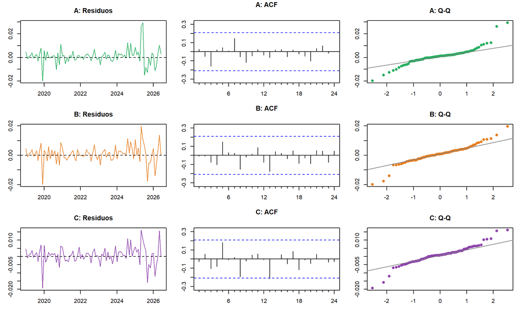

# 7 Backtesting

Se reservan los últimos 6 meses. Cada modelo se re-estima y se compara sobre **niveles de IPC pronosticados** (no en inflación interanual).

Backtesting — IPC pronosticado por modelo

| Fecha | IPC obs. | A: SARIMA | B: +Interv. | C: +TC |
| --- | --- | --- | --- | --- |
| ene 2026 | 149.06 | 148.46 | NA | NA |
| feb 2026 | 148.14 | 149.21 | NA | NA |
| mar 2026 | 147.63 | 150.34 | NA | NA |
| abr 2026 | 147.84 | 151.08 | NA | NA |
| may 2026 | 150.98 | 151.98 | NA | NA |
| jun 2026 | 154.22 | 152.54 | NA | NA |

Métricas de backtesting comparadas

| Métrica | A: SARIMA | B: +Interv. | C: +TC |
| --- | --- | --- | --- |
| RMSE (IPC) | 1.9643 | NaN | NaN |
| MAPE (IPC %) | 1.15% | NaN% | NaN% |

## 7.1 Backtesting - horizontes e inflacion

Se agregan horizontes de 6, 12 y 18 meses, y se visualiza el error fuera de muestra en inflacion mensual (MoM) e interanual (YoY).

Metricas de backtesting por horizonte

| Horizonte | Modelo | RMSE (IPC) | MAPE (IPC %) |
| --- | --- | --- | --- |
| 6 meses | A: SARIMA | 1.9643 | 1.15% |
| 6 meses | B: +Interv. | NaN | NaN% |
| 6 meses | C: +TC | NaN | NaN% |
| 12 meses | A: SARIMA | 33.0531 | 19.12% |
| 12 meses | B: +Interv. | NaN | NaN% |
| 12 meses | C: +TC | NaN | NaN% |
| 18 meses | A: SARIMA | 8.6124 | 5.36% |
| 18 meses | B: +Interv. | NaN | NaN% |
| 18 meses | C: +TC | NaN | NaN% |

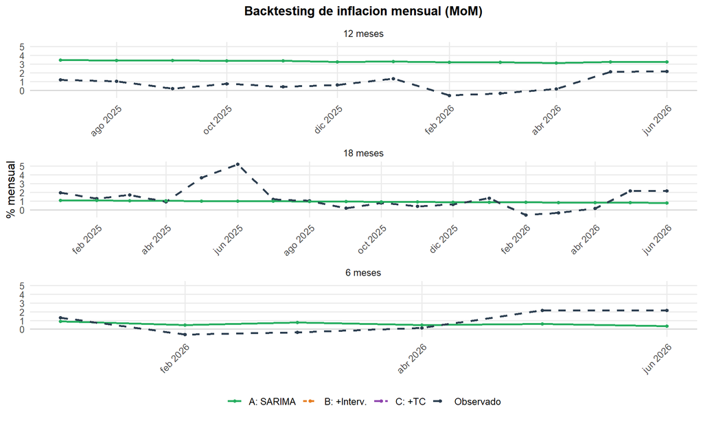

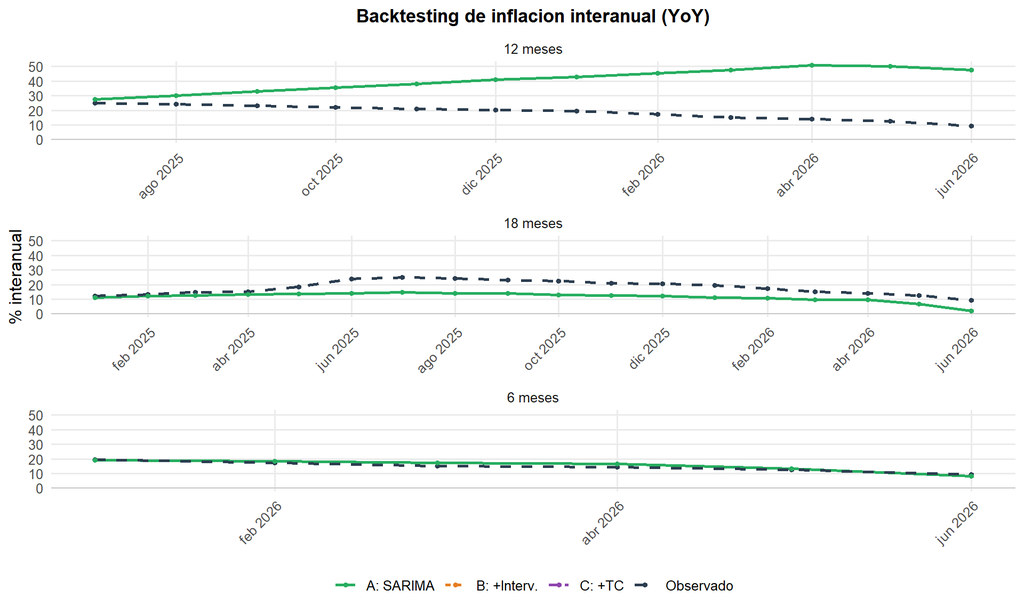

## 7.2 Backtesting - Top 10 candidatos por categoria

Antes de comparar los ganadores entre si, se muestra como habria pronosticado cada una de las 10 mejores alternativas de cada categoria (no solo la ganadora), reestimadas sobre el mismo periodo de entrenamiento. El ganador de cada categoria se resalta en color; el resto, en gris.

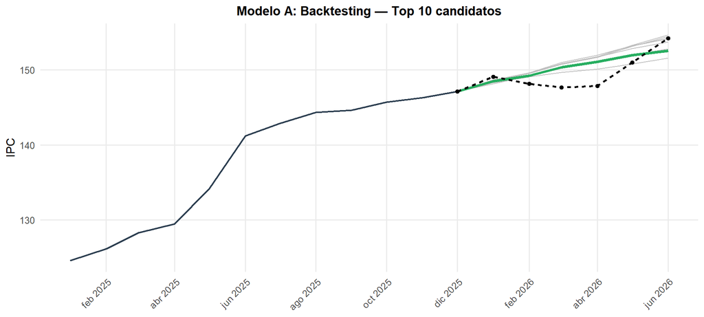

[figure not shown]

[figure not shown]

## 7.3 Backtesting — Comparación de ganadores

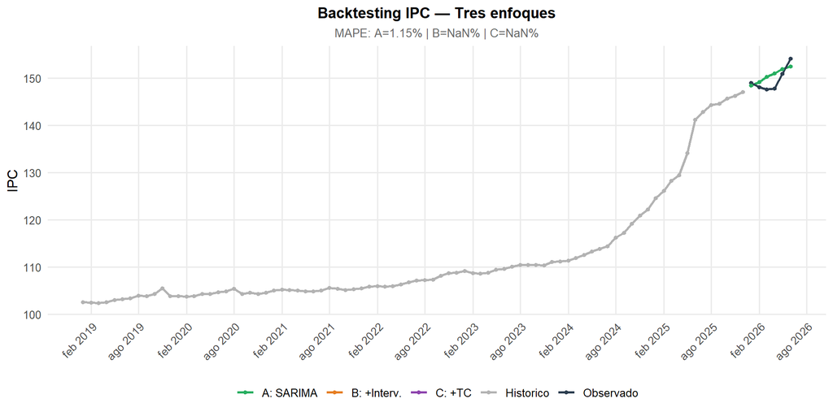

# 8 Pronóstico

## 8.1 Proyección comparada — Inflación

Proyección de inflación (%) — Tres enfoques

| Mes | A mens. | A interan. | B mens. | B interan. | C mens. | C interan. |
| --- | --- | --- | --- | --- | --- | --- |
| Julio | 0.682 | 8.67 | 0.348 | 8.31 | 0.071 | 8.01 |
| Agosto | 0.532 | 8.16 | 1.115 | 8.43 | 1.369 | 8.40 |
| Septiembre | 0.289 | 8.26 | 0.276 | 8.51 | 0.351 | 8.56 |
| Octubre | 0.400 | 7.88 | 0.444 | 8.18 | 0.840 | 8.66 |
| Noviembre | 0.295 | 7.77 | 0.297 | 8.07 | 0.562 | 8.84 |
| Diciembre | 0.310 | 7.47 | 0.345 | 7.81 | 0.595 | 8.84 |
| Enero | 0.543 | 6.66 | 0.580 | 7.03 | 0.774 | 8.27 |

## 8.2 Inflación interanual — Tres enfoques

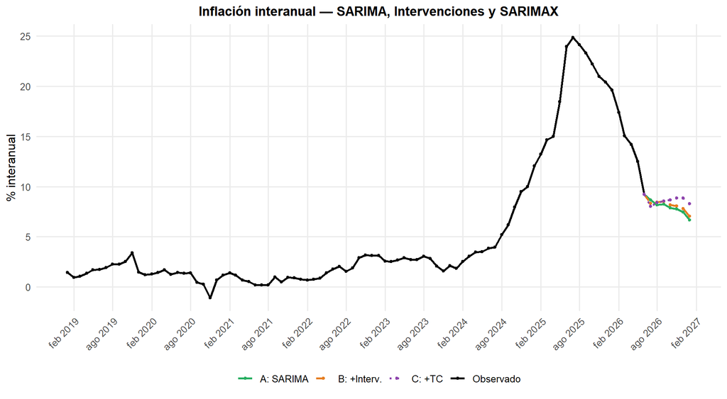

## 8.3 Contrafactual vs. Post-Bloqueos

El escenario “post-bloqueos” no se deriva del modelo: es una trayectoria construida externamente. La comparación siguiente debe leerse como una **brecha entre escenarios** (contrafactual **A (SARIMA puro)** vs. post-bloqueos), no como un efecto causal estimado.

Contrafactual A (SARIMA puro) vs. escenario post-bloqueos — Inflación interanual

| Mes | Mensual (%) | Interanual (%) — Contrafactual | Interanual (%) — Post-bloqueos | Diferencia (pp) |
| --- | --- | --- | --- | --- |
| Julio | 0.6818 | 8.67 | 10.12 | 1.44 |
| Agosto | 0.5317 | 8.16 | 10.54 | 2.38 |
| Septiembre | 0.2890 | 8.26 | 11.61 | 3.35 |
| Octubre | 0.4000 | 7.88 | 12.25 | 4.37 |
| Noviembre | 0.2952 | 7.77 | 13.05 | 5.29 |
| Diciembre | 0.3098 | 7.47 | 13.62 | 6.15 |

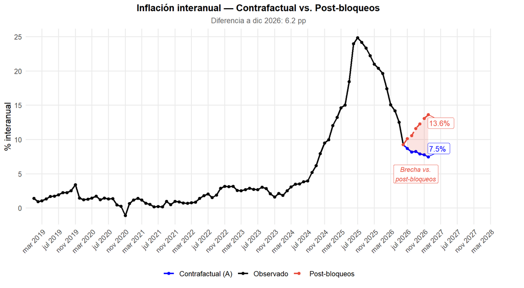

*Modelos estimados sobre log(IPC) desde 2019 (n=90).* *A: SARIMA puro | B: + dummies COVID, Bloqueos y shocks puntuales | C: + TC digital.*